# Deer Reproduction & Disease Control: Statistical Analyses (part 5)

*Damian Satterthwaite-Phillips*

### Fetal Size

We will consider fetal size in two different ways. First as the proportion ln(mass) / ln(crLength), recalling from before that this is a constant, regardless of the gestation age, and may be thought of as an idicator of the health or “robustness”, of the fetus. Next, we will look at total fetal mass, that is, the mass of all fetuses for a given mother. This latter metric can be thought of as a metric of the maternal investment for the pregnancy, rather than as a reflection of the health of any single fetus. We refer to these two metrics as “fetal size ratio”, and “total fetal mass” respectively.

##### Fetal Size Ratio

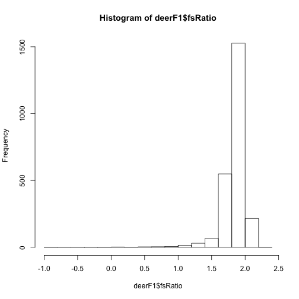

```r
deerF1$fsRatio = log(deerF1$wtMean) / log(deerF1$crMean)
hist(deerF1$fsRatio)
```

```r
shapiro.test(deerF1$fsRatio[
    !is.na(deerF1$fsRatio) & is.finite(deerF1$fsRatio)
])
```

```
##
##  Shapiro-Wilk normality test
##
## data:  deerF1$fsRatio[!is.na(deerF1$fsRatio) & is.finite(deerF1$fsRatio)]
## W = 0.70459, p-value < 2.2e-16
```

Note the left skew to the distribution of fetal size ratios, and that they are not easily normalized. We can consider a linear model, but as above, a GLM with a gamma-distributed response may be more appropriate. We explore both.

```r
fsr.lm.full = lm(fsRatio ~ (maleNo + femaleNo + age + intensity + cwd +
                 yearF + I(intensity^2) + I(maleNo^2) + I(femaleNo^2))^2 +
                 section - intensity:I(intensity^2) - maleNo:I(maleNo^2) -
                 femaleNo:I(femaleNo^2),
                 data = subset(deerF1, is.finite(fsRatio)) )
fsr.lm = step(fsr.lm.full, direction = 'both', trace = 0)
summary(fsr.lm)
```

```
##
## Call:
## lm(formula = fsRatio ~ maleNo + femaleNo + age + intensity +
##     cwd + yearF + I(intensity^2) + I(maleNo^2) + I(femaleNo^2) +
##     maleNo:femaleNo + maleNo:age + maleNo:intensity + maleNo:yearF +
##     maleNo:I(femaleNo^2) + femaleNo:age + femaleNo:intensity +
##     femaleNo:yearF + femaleNo:I(intensity^2) + femaleNo:I(maleNo^2) +
##     age:intensity + age:I(maleNo^2) + age:I(femaleNo^2) + cwd:I(intensity^2) +
##     yearF:I(femaleNo^2) + I(intensity^2):I(maleNo^2), data = subset(deerF1,
##     is.finite(fsRatio)))
##
## Residuals:
##      Min       1Q   Median       3Q      Max
## -1.80563 -0.06787  0.01661  0.08992  0.69331
##
## Coefficients:
##                              Estimate Std. Error t value Pr(>|t|)
## (Intercept)                 1.394e+00  7.498e-02  18.589  < 2e-16 ***
## maleNo                      6.104e-01  6.510e-02   9.376  < 2e-16 ***
## femaleNo                    6.412e-01  1.214e-01   5.280 1.41e-07 ***
## ageyearling                 2.746e-01  4.332e-02   6.339 2.77e-10 ***
## ageadult                    2.594e-01  3.687e-02   7.035 2.60e-12 ***
## intensity                  -1.613e-02  2.900e-03  -5.562 2.97e-08 ***
## cwdpos                     -3.531e-02  2.447e-02  -1.443 0.149066
## yearF2004                  -2.794e-01  8.012e-02  -3.487 0.000497 ***
## yearF2005                  -1.158e-01  8.041e-02  -1.440 0.150053
## yearF2006                  -6.082e-02  7.834e-02  -0.776 0.437651
## yearF2007                  -1.714e-01  7.755e-02  -2.211 0.027164 *
## yearF2008                  -2.669e-01  7.790e-02  -3.425 0.000624 ***
## yearF2009                  -1.405e-01  8.345e-02  -1.684 0.092298 .
## yearF2010                  -1.234e-01  8.632e-02  -1.429 0.153063
## yearF2011                  -1.409e-01  7.897e-02  -1.784 0.074493 .
## yearF2012                  -8.199e-02  8.468e-02  -0.968 0.333025
## I(intensity^2)              2.718e-04  8.742e-05   3.108 0.001903 **
## I(maleNo^2)                -2.003e-01  2.919e-02  -6.861 8.72e-12 ***
## I(femaleNo^2)              -1.995e-01  6.437e-02  -3.100 0.001959 **
## maleNo:femaleNo            -4.182e-01  3.803e-02 -10.995  < 2e-16 ***
## maleNo:ageyearling         -2.834e-01  6.131e-02  -4.623 4.00e-06 ***
## maleNo:ageadult            -2.119e-01  5.414e-02  -3.914 9.34e-05 ***
## maleNo:intensity            3.892e-03  1.583e-03   2.459 0.014011 *
```

[output cut: 33 more lines]

```
## yearF2006:I(femaleNo^2)     5.262e-03  5.938e-02   0.089 0.929386
## yearF2007:I(femaleNo^2)    -2.240e-02  5.927e-02  -0.378 0.705469
## yearF2008:I(femaleNo^2)    -3.663e-02  5.968e-02  -0.614 0.539453
## yearF2009:I(femaleNo^2)    -1.938e-02  6.042e-02  -0.321 0.748419
## yearF2010:I(femaleNo^2)    -2.197e-02  6.116e-02  -0.359 0.719511
## yearF2011:I(femaleNo^2)    -1.083e-02  5.939e-02  -0.182 0.855370
## yearF2012:I(femaleNo^2)    -3.376e-02  6.083e-02  -0.555 0.578956
## I(intensity^2):I(maleNo^2) -5.569e-05  2.625e-05  -2.121 0.033986 *
## ---
## Signif. codes:  0 '***' 0.001 '**' 0.01 '*' 0.05 '.' 0.1 ' ' 1
##
## Residual standard error: 0.1548 on 2337 degrees of freedom
##   (21 observations deleted due to missingness)
## Multiple R-squared:  0.2841, Adjusted R-squared:  0.2648
## F-statistic: 14.72 on 63 and 2337 DF,  p-value: < 2.2e-16
```

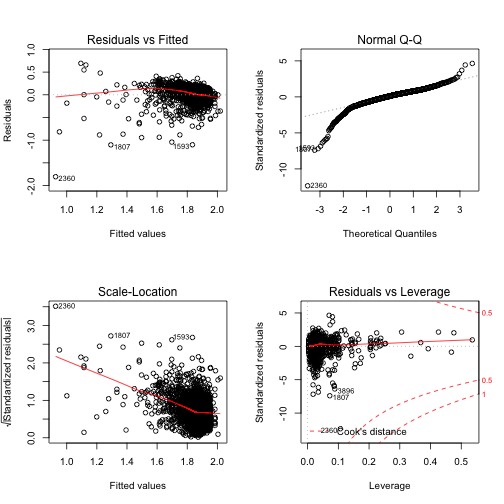

```r
par(mfrow = c(2, 2))
plot(fsr.lm)
```

This model has an r<sup>2</sup> of 0.28, but it is clear that the screw in the response is carried over into the residuals, and there may be some slight heteroskedasticity as well. Checking the GLM:

```r
#fsr.glm.full = glm(fsRatio ~ (maleNo + femaleNo + age + intensity + cwd +
#                  yearF + I(intensity^2) + I(maleNo^2) + I(femaleNo^2))^2 +
#                  section - intensity:I(intensity^2) - maleNo:I(maleNo^2) -
#                  femaleNo:I(femaleNo^2),
#                  data = subset(deerF1, is.finite(fsRatio) & fsRatio >= 0),
#                  family = Gamma(link = 'inverse') )
#fsr.glm = step(fsr.glm.full, direction = 'both', trace = 1)
fsr.glm.full = glm(fsRatio ~ (maleNo + femaleNo + age + intensity + cwd +
                   yearF + I(intensity^2) + I(maleNo^2) + I(femaleNo^2))^2 -
                   intensity:I(intensity^2) - maleNo:I(maleNo^2) -
                   femaleNo:I(femaleNo^2) - age:yearF - yearF:I(maleNo^2) -
                   cwd:yearF - intensity:yearF - yearF:I(intensity^2) -
                   age:I(intensity^2) - maleNo:intensity - cwd:I(maleNo^2) -
                   yearF:I(femaleNo^2) - I(maleNo^2):I(femaleNo^2) - age:cwd
                   - maleNo:cwd - maleNo:I(intensity^2) -
                   intensity:I(maleNo^2) - I(intensity^2):I(maleNo^2) -
                   I(intensity^2):I(femaleNo^2) - femaleNo:I(intensity^2) -
                   intensity:I(femaleNo^2) - cwd:I(femaleNo^2) - femaleNo:cwd
                   - intensity:cwd - cwd:I(intensity^2) - cwd,
                   data = subset(deerF1, is.finite(fsRatio) & fsRatio >= 0),
                   family = Gamma(link = 'inverse') )
fsr.glm = step(fsr.glm.full, direction = 'both', trace = 0)
summary(fsr.glm)
```

```
##
## Call:
## glm(formula = fsRatio ~ (maleNo + femaleNo + age + intensity +
##     cwd + yearF + I(intensity^2) + I(maleNo^2) + I(femaleNo^2))^2 -
##     intensity:I(intensity^2) - maleNo:I(maleNo^2) - femaleNo:I(femaleNo^2) -
##     age:yearF - yearF:I(maleNo^2) - cwd:yearF - intensity:yearF -
##     yearF:I(intensity^2) - age:I(intensity^2) - maleNo:intensity -
##     cwd:I(maleNo^2) - yearF:I(femaleNo^2) - I(maleNo^2):I(femaleNo^2) -
##     age:cwd - maleNo:cwd - maleNo:I(intensity^2) - intensity:I(maleNo^2) -
##     I(intensity^2):I(maleNo^2) - I(intensity^2):I(femaleNo^2) -
##     femaleNo:I(intensity^2) - intensity:I(femaleNo^2) - cwd:I(femaleNo^2) -
##     femaleNo:cwd - intensity:cwd - cwd:I(intensity^2) - cwd,
##     family = Gamma(link = "inverse"), data = subset(deerF1, is.finite(fsRatio) &
##         fsRatio >= 0))
##
## Deviance Residuals:
##      Min        1Q    Median        3Q       Max
## -1.61739  -0.03849   0.00936   0.04874   0.36716
##
## Coefficients:
##                             Estimate Std. Error t value Pr(>|t|)
## (Intercept)                7.028e-01  2.511e-02  27.991  < 2e-16 ***
## maleNo                    -1.972e-01  2.219e-02  -8.889  < 2e-16 ***
## femaleNo                  -2.301e-01  2.266e-02 -10.153  < 2e-16 ***
## ageyearling               -9.453e-02  1.458e-02  -6.484 1.09e-10 ***
## ageadult                  -8.678e-02  1.268e-02  -6.842 9.96e-12 ***
## intensity                  2.497e-03  6.025e-04   4.144 3.53e-05 ***
## yearF2004                  4.665e-02  2.642e-02   1.765 0.077636 .
## yearF2005                  3.291e-02  2.609e-02   1.261 0.207265
## yearF2006                  3.330e-02  2.526e-02   1.318 0.187543
## yearF2007                  6.075e-02  2.519e-02   2.411 0.015982 *
## yearF2008                  8.914e-02  2.509e-02   3.553 0.000389 ***
## yearF2009                  4.338e-02  2.682e-02   1.617 0.105962
## yearF2010                  4.265e-02  2.730e-02   1.562 0.118325
## yearF2011                  4.259e-02  2.535e-02   1.680 0.093041 .
## yearF2012                  2.388e-02  2.679e-02   0.891 0.372790
## I(intensity^2)            -2.953e-05  1.187e-05  -2.487 0.012936 *
## I(maleNo^2)                6.287e-02  9.921e-03   6.337 2.80e-10 ***
## I(femaleNo^2)              7.427e-02  9.239e-03   8.039 1.42e-15 ***
## maleNo:femaleNo            1.333e-01  1.255e-02  10.621  < 2e-16 ***
```

[output cut: 27 more lines]

```
## ageyearling:I(maleNo^2)   -2.951e-02  1.061e-02  -2.782 0.005447 **
## ageadult:I(maleNo^2)      -2.294e-02  9.808e-03  -2.339 0.019426 *
## ageyearling:I(femaleNo^2) -2.495e-02  1.035e-02  -2.410 0.016043 *
## ageadult:I(femaleNo^2)    -3.831e-02  8.993e-03  -4.260 2.12e-05 ***
## ---
## Signif. codes:  0 '***' 0.001 '**' 0.01 '*' 0.05 '.' 0.1 ' ' 1
##
## (Dispersion parameter for Gamma family taken to be 0.008001238)
##
##     Null deviance: 31.505  on 2399  degrees of freedom
## Residual deviance: 25.648  on 2350  degrees of freedom
##   (21 observations deleted due to missingness)
## AIC: -1071.8
##
## Number of Fisher Scoring iterations: 4
```

```r
library(fmsb)
NagelkerkeR2(fsr.glm)
```

```
## $N
## [1] 2400
##
## $R2
## [1] 0.186916
```

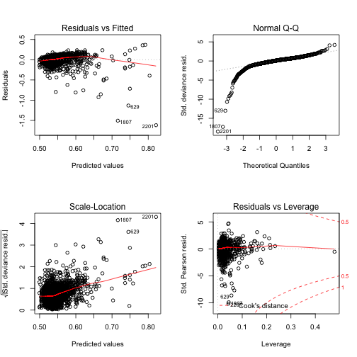

```r
par(mfrow = c(2, 2))
plot(fsr.glm)
```

The GLM model shares the concern with the lm regarding slight heteroskedasticity, but in terms of significant predictors, the two models are in considerable agreement. The table below compares the significance of the predictors in the two models.

| Predictor | LM | GLM |
| --- | --- | --- |
| intercept | *** | *** |
| maleNo | *** | *** |
| femaleNo | *** | *** |
| age | *** | *** |
| yearF | *** | *** |
| int^2 | ** | * |
| maleNo^2 | *** | *** |
| femaleNo^2 | ** | *** |
| m:f | *** | *** |
| m:age | *** | *** |
| m:year | * | * |
| m:f^2 | *** | *** |
| f:age | *** | *** |
| f:int | ** | - |
| f:year | * | * |
| f:m^2 | *** | *** |
| age:int | ** | * |
| age:m^2 | ** | ** |
| age:f^2 | *** | * |
| int^2:m^2 | * | - |

Next we examine the predicted effects of the culling intensity on the fetal size ratio given by the two models.

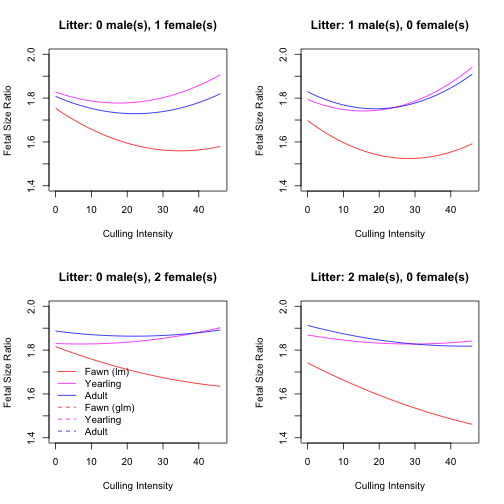

```r
intV = seq(0, max(deerF1$intensity, na.rm = T), length = 100)

predPlot = function(mNo, fNo, yr) {
    pred = function(mod, ag, ...) {
        predict(mod, newdata = data.frame(
            maleNo = mNo,
            femaleNo = fNo,
            age = ag,
            yearF = yr,
            intensity = intV,
            cwd = 'neg'
        ))
    }

    f.lm.pred = pred(fsr.lm, 'fawn')
    y.lm.pred = pred(fsr.lm, 'yearling')
    a.lm.pred = pred(fsr.lm, 'adult')

    f.glm.pred = pred(fsr.glm, 'fawn', type = 'response')
    y.glm.pred = pred(fsr.glm, 'yearling', type = 'response')
    a.glm.pred = pred(fsr.glm, 'adult', type = 'response')

    plot(f.lm.pred ~ intV, type = 'l', col = 2,
         ylim = c(1.4, 2),
         xlab = 'Culling Intensity', ylab = 'Fetal Size Ratio',
         main = paste('Litter: ', mNo, ' male(s), ', fNo, ' female(s)',
                      sep = ''))
    lines(y.lm.pred ~ intv, col = 6)
    lines(a.lm.pred ~ intv, col = 4)
    lines(f.glm.pred ~ intV, col = 2, lty = 2)
    lines(y.glm.pred ~ intV, col = 6, lty = 2)
    lines(a.glm.pred ~ intV, col = 4, lty = 2)

}

par(mfrow = c(2, 2))
predPlot(0, 1, '2009')
predPlot(1, 0, '2009')
predPlot(0, 2, '2009')
legend('bottomleft', lty = c(1, 1, 1, 2, 2, 2), col = c(2, 6, 4),
       legend = c('Fawn (lm)', 'Yearling', 'Adult',
                  'Fawn (glm)', 'Yearling', 'Adult'), bty = 'n')
predPlot(2, 0, '2009')
```

For adults and yearlings, the effect of culling intensity of the fetal size ratio is nearly flat. The relationship is nonlinear, but suggests perhaps a slight increase in the ratio (e.g. more mass for the same length, or “more robust”) at the highest intensity levels. Fawns, by contrast, show a noticeable decline in the ratio (“less robust fetuses”) as the culling intensity increases. The exact effect is predicted to depend on the total number of fetuses, as well as the sexes of those fetuses, but the overall pattern is consistent.

##### Total Fetal Mass

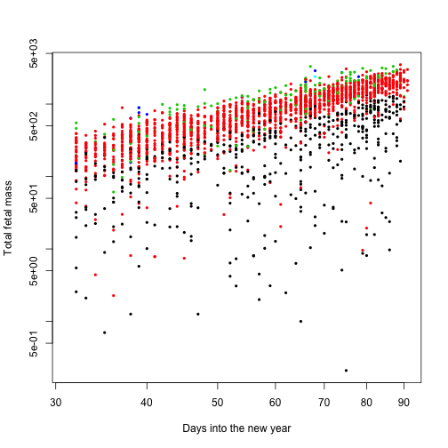

```r
par(mfrow = c(1, 1))
plot(wtTotal ~ days, deerF1, xlim = c(31, 91), col = fetusNo, pch = 16,
     cex = 0.6, log = 'xy', xlab = 'Days into the new year',
     ylab = 'Total fetal mass')
```

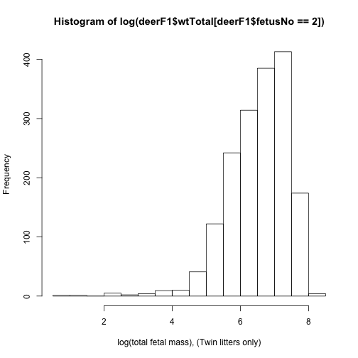

```r
hist(log(deerF1$wtTotal[deerF1$fetusNo == 2]),
     xlab = 'log(total fetal mass), (Twin litters only)')
```

```r
shapiro.test(deerF1$wtTotal[deerF1$fetusNo == 2]^0.39)
```

```
##
##  Shapiro-Wilk normality test
##
## data:  deerF1$wtTotal[deerF1$fetusNo == 2]^0.39
## W = 0.99004, p-value = 1.726e-09
```

Note that the axes in the first of the above two images is are log-log, indicating that the log of the total fetal mass is in an approximately linear relationship with log number of days into the year, but as the histogram (and scatterplot) show, the distribution shows considerable left skew, and the data are not easily normalized. In the previous set of models, the log(mass) to log(length) ratio was constant, with errors randomly distributed, so the date did not have to be taken into consideration. Here however, while the ratio of log(total fetal mass) is in constant proportion to the log(days), the errors are not normally distributed around that constant, as the above graphs indicate. Hence we specifically add the date into the set of predictors, and procede as before.

```r
tfm.glm.full = glm((log(wtTotal) + 2) ~ (maleNo + femaleNo + age + intensity
                   + cwd + yearF + I(intensity^2) + I(maleNo^2) +
                   I(femaleNo^2) + log(days))^2 + section -
                   intensity:I(intensity^2) - maleNo:I(maleNo^2) -
                   femaleNo:I(femaleNo^2),
                   data = subset(deerF1, !is.na(log(wtTotal))),
                   family = Gamma(link = 'inverse'))
tfm.glm = step(tfm.glm.full, direction = 'both', trace = 0)
summary(tfm.glm)
```

```
##
## Call:
## glm(formula = (log(wtTotal) + 2) ~ maleNo + femaleNo + age +
##     intensity + cwd + yearF + I(intensity^2) + I(maleNo^2) +
##     I(femaleNo^2) + log(days) + maleNo:femaleNo + maleNo:age +
##     maleNo:yearF + maleNo:log(days) + femaleNo:age + femaleNo:intensity +
##     femaleNo:cwd + femaleNo:yearF + femaleNo:log(days) + age:intensity +
##     age:I(maleNo^2) + age:I(femaleNo^2) + age:log(days) + intensity:cwd +
##     cwd:yearF + cwd:I(intensity^2) + cwd:I(femaleNo^2) + I(maleNo^2):I(femaleNo^2),
##     family = Gamma(link = "inverse"), data = subset(deerF1, !is.na(log(wtTotal))))
##
## Deviance Residuals:
##      Min        1Q    Median        3Q       Max
## -1.74582  -0.02643   0.00626   0.03829   0.44660
##
## Coefficients:
##                             Estimate Std. Error t value Pr(>|t|)
## (Intercept)                4.930e-01  1.778e-02  27.720  < 2e-16 ***
## maleNo                    -9.551e-02  8.825e-03 -10.823  < 2e-16 ***
## femaleNo                  -1.156e-01  8.762e-03 -13.188  < 2e-16 ***
## ageyearling               -1.280e-01  1.633e-02  -7.834 7.11e-15 ***
## ageadult                  -1.238e-01  1.491e-02  -8.303  < 2e-16 ***
## intensity                  5.187e-04  1.385e-04   3.746 0.000184 ***
## cwdpos                     1.213e-02  8.117e-03   1.495 0.135143
## yearF2004                  1.163e-02  5.957e-03   1.952 0.051060 .
## yearF2005                  1.092e-02  5.743e-03   1.901 0.057419 .
## yearF2006                  1.189e-02  5.602e-03   2.122 0.033917 *
## yearF2007                  1.655e-02  5.580e-03   2.966 0.003043 **
## yearF2008                  1.652e-02  5.520e-03   2.992 0.002797 **
## yearF2009                  1.317e-02  5.904e-03   2.231 0.025779 *
## yearF2010                 -1.314e-03  6.061e-03  -0.217 0.828337
## yearF2011                  9.128e-03  5.576e-03   1.637 0.101785
## yearF2012                  2.519e-03  5.914e-03   0.426 0.670161
## I(intensity^2)            -1.365e-06  2.569e-06  -0.532 0.595049
## I(maleNo^2)                1.432e-02  2.138e-03   6.698 2.64e-11 ***
## I(femaleNo^2)              1.659e-02  2.005e-03   8.274  < 2e-16 ***
## log(days)                 -7.169e-02  3.913e-03 -18.323  < 2e-16 ***
## maleNo:femaleNo            2.243e-02  1.561e-03  14.374  < 2e-16 ***
## maleNo:ageyearling         2.942e-02  4.478e-03   6.570 6.19e-11 ***
## maleNo:ageadult            2.596e-02  4.020e-03   6.458 1.29e-10 ***
```

[output cut: 41 more lines]

```
## cwdpos:yearF2012          -1.523e-02  9.288e-03  -1.640 0.101169
## cwdpos:I(intensity^2)     -5.805e-05  2.555e-05  -2.273 0.023141 *
## cwdpos:I(femaleNo^2)      -5.454e-03  3.575e-03  -1.526 0.127252
## I(maleNo^2):I(femaleNo^2) -2.863e-03  3.896e-04  -7.348 2.76e-13 ***
## ---
## Signif. codes:  0 '***' 0.001 '**' 0.01 '*' 0.05 '.' 0.1 ' ' 1
##
## (Dispersion parameter for Gamma family taken to be 0.007251466)
##
##     Null deviance: 59.125  on 2404  degrees of freedom
## Residual deviance: 21.688  on 2337  degrees of freedom
##   (21 observations deleted due to missingness)
## AIC: 5759.8
##
## Number of Fisher Scoring iterations: 4
```

```r
NagelkerkeR2(tfm.glm)
```

```
## $N
## [1] 2405
##
## $R2
## [1] 0.636027
```

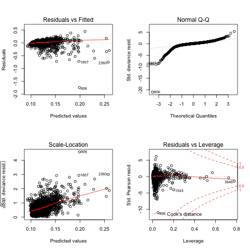

```r
par(mfrow = c(2, 2))
plot(tfm.glm)
```

As before, there may be some slight concern about the non-constant variance in the residuals, so we will revisit this question in some of the other sections as well. For now, though, we again investigate the effect of the culling intensity on the total fetal mass.

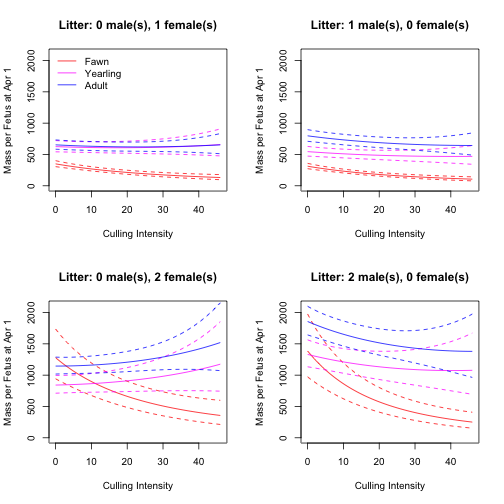

```r
predPlot2 = function(mNo, fNo, yr, yl = NULL) {
    pred = function(mod, ag) {
        p = predict(
            mod, newdata = data.frame(
                maleNo = mNo,
                femaleNo = fNo,
                age = ag,
                yearF = yr,
                intensity = intV,
                cwd = 'neg',
                days = 91
            ), type = 'response', se.fit = T

        )

        return (list(fit = exp(p$fit - 2),
                     seH = exp(p$fit + p$se.fit - 2),
                     seL = exp(p$fit - p$se.fit - 2)
        ))
    }

    f.pred = pred(tfm.glm, ag = 'fawn')
    y.pred = pred(tfm.glm, ag = 'yearling')
    a.pred = pred(tfm.glm, ag = 'adult')

    if (is.null(yl)) {
        yl = c(0, max(c(f.pred$seH, y.pred$seH, a.pred$seH)))
    }

    plot(f.pred$fit / (mNo + fNo) ~ intV, type = 'l', col = 2,
         ylim = yl,
         xlab = 'Culling Intensity', ylab = 'Mass per Fetus at Apr 1',
         main = paste('Litter: ', mNo, ' male(s), ', fNo, ' female(s)',
                      sep = ''))
    lines(f.pred$seH / (mNo + fNo) ~ intV, col = 2, lty = 2)
    lines(f.pred$seL / (mNo + fNo) ~ intV, col = 2, lty = 2)
    lines(y.pred$fit / (mNo + fNo) ~ intv, col = 6)
    lines(y.pred$seH / (mNo + fNo) ~ intV, col = 6, lty = 2)
    lines(y.pred$seL / (mNo + fNo) ~ intV, col = 6, lty = 2)
    lines(a.pred$fit / (mNo + fNo) ~ intv, col = 4)
    lines(a.pred$seH / (mNo + fNo) ~ intV, col = 4, lty = 2)
    lines(a.pred$seL / (mNo + fNo) ~ intV, col = 4, lty = 2)
}

par(mfrow = c(2, 2))
predPlot2(0, 1, '2008', yl = c(0, 2100))
legend('topleft', lty = 1, col = c(2, 6, 4),
       legend = c('Fawn', 'Yearling', 'Adult'), bty = 'n')
predPlot2(1, 0, '2008', yl = c(0, 2100))
predPlot2(0, 2, '2008', yl = c(0, 2100))
predPlot2(2, 0, '2008', yl = c(0, 2100))
```